# Final Capstone Project Johns Hopkins University MileStone Report

Andrew Delos Santos

11/22/2019

### Abstract

For this particular project, the goal is to develop a predictive text model from a corpus of text documents provided by Swiftkey, the partner for this particular capstone. The project will go through the necessary procedures of having the data cleaned along with exploratory data analysis for this stage of the project. The libraries that will help for this particular part of the project are the tm and ngram packages in order to conduct n-gram data and to use tm function features. We first start with obtaining the data and cleaning it to make it cleaner.

### Getting and Cleaning the Data

```r
##Load libraries and packages
library(tm)
library(stringr)
library(dplyr)
```

```r
library(ggplot2)
library(stopwords)
library(RColorBrewer)
library(wordcloud)
library(ngram)
library(stringr)

##Cleaning Data for the Twitter Data
#Read in the Twitter file and open as read only to read the lines
#Close connection and make sure to split all punctuation
twitter_file <- "final/en_US/en_US.twitter.txt"
twitter_connection <- file(twitter_file, "r")
twitter_lines <- readLines(twitter_connection, skipNul = T)
close(twitter_connection)
twitter_lines_lower <- tolower(twitter_lines)
twitter_lines_lower_updated <- unlist(strsplit(twitter_lines_lower, "[.,:;!?(){}<>]+"))

#Take data and replace all non-alphanumeric with space at beginning/end of a word
#Remove multiple spaces and spaces at the beginning and end of a line
#Remove multiple spaces and then remove spaces at the beginning and end of line
cleaned_twitter <- twitter_lines_lower_updated %>%
  {gsub("^[^a-z0-9]+|[^a-z0-9]+$", " ", twitter_lines_lower_updated)} %>%
  {gsub("[^a-z0-9]+\\s", " ", twitter_lines_lower_updated)} %>%
  {gsub("\\s[^a-z0-9]+", " ", twitter_lines_lower_updated)} %>%
  {gsub("\\s+", " ", twitter_lines_lower_updated)} %>%
  {str_trim(twitter_lines_lower_updated)}
  head(cleaned_twitter, 20)
```

```
##  [1] "how are you"
##  [2] "btw thanks for the rt"
##  [3] "you gonna be in dc anytime soon"
##  [4] "love to see you"
##  [5] "been way"
##  [6] "way too long"
##  [7] "when you meet someone special"
##  [8] "you'll know"
##  [9] "your heart will beat more rapidly and you'll smile for no reason"
## [10] "they've decided its more fun if i don't"
## [11] "so tired d"
## [12] "played lazer tag & ran a lot d"
## [13] "ughh going to sleep like in 5 minutes"
## [14] "words from a complete stranger"
## [15] "made my birthday even better"
## [16] "first cubs game ever"
## [17] "wrigley field is gorgeous"
## [18] "this is perfect"
## [19] "go cubs go"
## [20] "i no"
```

```r
#Save in an rds file
saveRDS(cleaned_twitter, "cleaned_twitter.rds")
```

### Exploratory Data Analysis of N-gram models

## 1-Gram Exploratory Analysis

I analyzed 1-gram models on the Twitter data and created exploratory graphs in order to get a better picture of what was happening. I also then analyzed both 1-gram with and without stopwords. The findings were pretty interesting as a result. From the data, it was not surprising to find that the was the most common word with all stopwords and that just was the most common word without any stopwords. Also, it was very interesting to see that as more words increased, the count of the top 250 words decreased.

```r
##1-Gram Exploratory Data Analysis with StopWords
#Create a table of one-gram words and create a data frame of the data to easily
#pull elements from the data frame.
one_gram <- unlist(strsplit(cleaned_twitter, "\\s+"))
one_gram.frequency <- table(one_gram)
one_gram_df <- cbind.data.frame(names(one_gram.frequency), as.integer(one_gram.frequency))
names(one_gram_df) <- c("word", "frequency")
row.names(one_gram_df) <- one_gram_df[,1]
one_gram_df <- one_gram_df[order(-one_gram_df[["frequency"]]), ]
#Look at the first 20 1-gram words and create exploratory graphs/visualizations
head(one_gram_df, 20)
```

```
##      word frequency
## the   the    929181
## to     to    786567
## i       i    717095
## a       a    608541
## you   you    543257
## and   and    436876
## for   for    384603
## in     in    376652
## of     of    358951
## is     is    357992
## it     it    292620
## my     my    290583
## on     on    276473
## that that    233720
## me     me    201127
## be     be    187131
## at     at    185656
## with with    173172
## your your    170483
## have have    168265
```

```r
one_gram_df["i'm", ]
```

```
##     word frequency
## i'm  i'm    127694
```

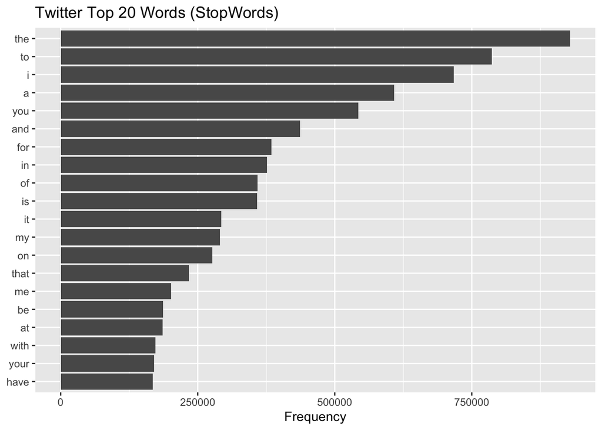

```r
plot_one_gram <- ggplot(one_gram_df[1:20, ], aes(x = reorder(word, frequency), frequency)) +
geom_col() + xlab(NULL) + coord_flip() +
labs(title = "Twitter Top 20 Words (StopWords)", x = NULL, y = "Frequency")
plot_one_gram
```

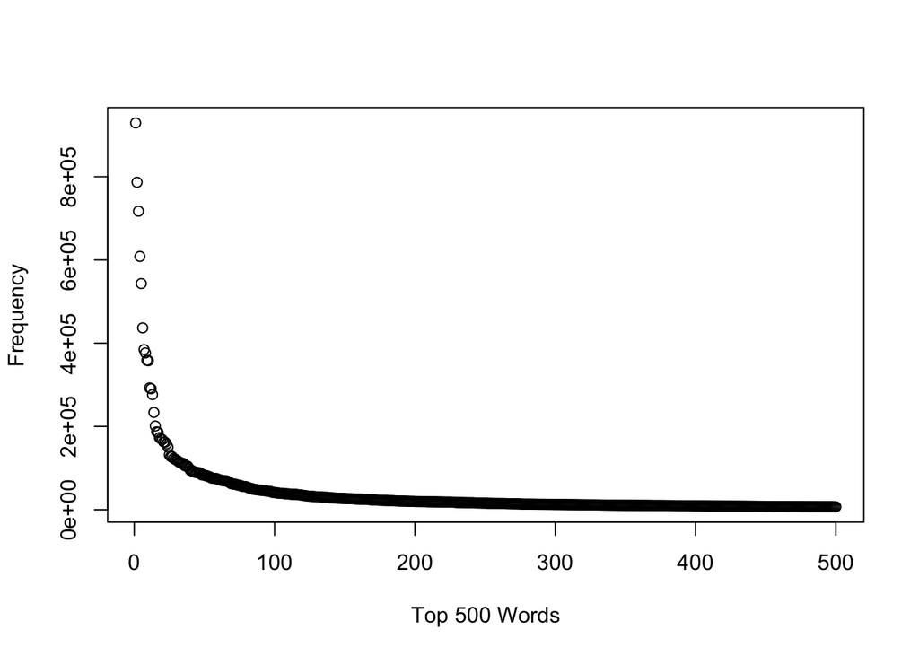

```r
plot(one_gram_df[1:500,][["frequency"]], xlab = "Top 500 Words", ylab = "Frequency")
```

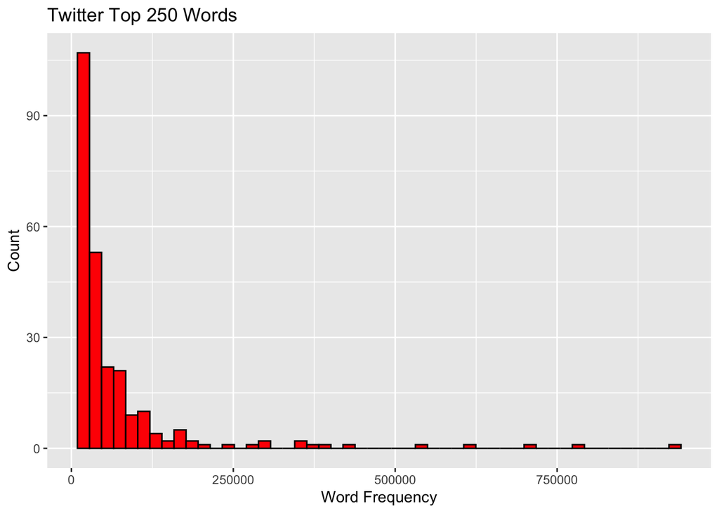

```r
one_gram_histogram <- ggplot(one_gram_df[1:250, ], aes(x = one_gram_df[1:250,][["frequency"]])) +
geom_histogram(colour = "black", fill = "red", bins = 50) +
labs(title = "Twitter Top 250 Words", x = "Word Frequency", y = "Count")
one_gram_histogram
```

```r
saveRDS(one_gram_df, "one_gram_df.rds")
#Data Cleaning No StopWords
#Create function to see stopwords. Subset and obtain words from the column
#of the data frame and if it equals stop return the value then unlist the values
#and create a new data frame to then see the 1-gram words that are not stopwords.
f1 <- function(stop){
  return(which(one_gram_df[["word"]] == stop))
}
x1 <- unlist(lapply(stopwords("en"), f1))
one_gram_df_no_stop <- one_gram_df[-x1, ]
head(one_gram_df_no_stop, 20)
```

```
##          word frequency
## just     just    150433
## like     like    121056
## get       get    111822
## love     love    105094
## good     good     99908
## -           -     94422
## &           &     91471
## can       can     89265
## thanks thanks     89172
## day       day     89121
## rt         rt     88275
## now       now     83236
## one       one     81219
## know     know     79455
## u           u     78577
## great   great     75667
## time     time     74965
## today   today     72358
## go         go     71955
## lol       lol     69611
```

[figure not shown]

```r
saveRDS(one_gram_df_no_stop, "one_gram_df_no_stop.rds")
#Exploratory Data Analysis No StopWords
ggplot(one_gram_df_no_stop[1:20, ], aes(x = reorder(word, frequency), frequency)) +
geom_col() +
xlab(NULL) +
coord_flip() +
labs(title = "Twitter Top 20 Words (No StopWords)", x = NULL, y = "Frequency")
```

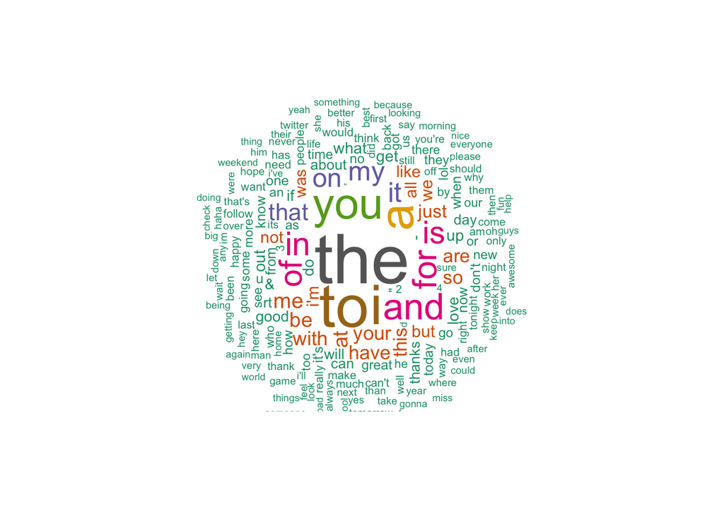

```r
#Generate Word Clouds for StopWords/No StopWords
set.seed(1234)
wordcloud(words = one_gram_df[["word"]], freq = one_gram_df[["frequency"]], min.freq = 1, max.words = 200, random.order = F, rot.per = 0.35, colors = brewer.pal(8, "Dark2"))
```

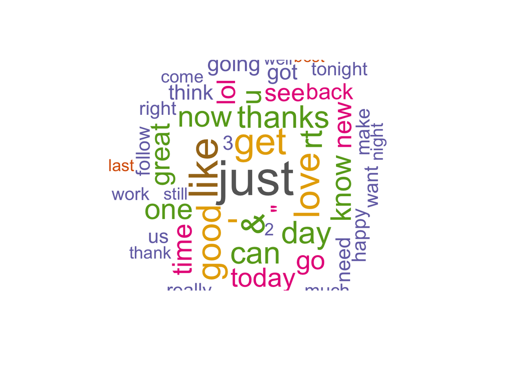

```r
set.seed(1000)
wordcloud(words = one_gram_df_no_stop[["word"]], freq = one_gram_df_no_stop[["frequency"]], min.freq = 1, max.words = 50, random.order = F, rot.per = 0.35, colors = brewer.pal(8, "Dark2"))
```

## 2-gram Exploratory Analysis

For the 2-gram exploratory analysis, I found it very interesting how the length of the cleaned twitter lines was 5398325 lines long. Also, the top 2-gram phrase with stopwords was “in the”.

```r
##2-Gram Exploratory Data Analysis StopWords
#Repeat same steps as the 1-gram model.
cleaned_twitter[1]
```

```
## [1] "how are you"
```

```r
twitter_final_two_gram <- cleaned_twitter[str_count(cleaned_twitter, "\\s+") > 0]
length(cleaned_twitter)
```

```
## [1] 5398325
```

```r
two_gram <- ngram(twitter_final_two_gram, n = 2)
two_gram_df <- get.phrasetable(two_gram)
head(two_gram_df, 20)
```

```
##         ngrams  freq        prop
## 1      in the  77693 0.003094877
## 2     for the  73649 0.002933786
## 3      of the  56497 0.002250541
## 4      on the  48042 0.001913739
## 5       to be  46829 0.001865419
## 6      to the  43082 0.001716159
## 7  thanks for  42746 0.001702774
## 8      at the  37025 0.001474880
## 9      i love  35214 0.001402739
## 10   going to  34214 0.001362904
## 11     have a  33644 0.001340199
## 12  thank you  32968 0.001313270
## 13     if you  32473 0.001293552
## 14     i have  31240 0.001244436
## 15      for a  29546 0.001176956
## 16       i am  29294 0.001166918
## 17     to get  26886 0.001070996
## 18     to see  26825 0.001068566
## 19       is a  26632 0.001060878
## 20    will be  25720 0.001024549
```

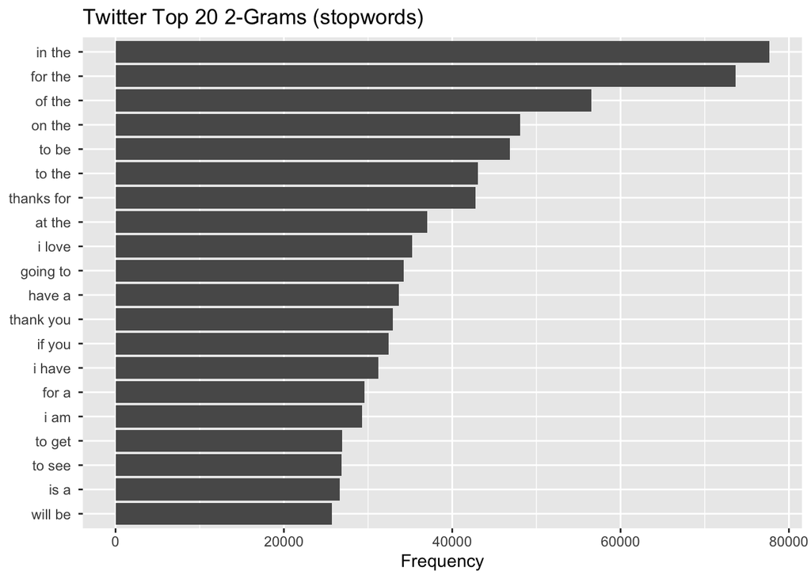

```r
ngrams <- two_gram_df[["ngrams"]]
freq <- two_gram_df[["freq"]]
ggplot(two_gram_df[1:20, ], aes(x = reorder(ngrams, freq), freq)) +
geom_col() +
xlab(NULL) +
coord_flip() +
labs(title = "Twitter Top 20 2-Grams (stopwords)", x = NULL, y = "Frequency")
```

```r
saveRDS(two_gram_df, "two_gram_df.rds")
```

## 3-gram Exploratory Analysis

I then moved onto a 3-gram exploratory data analysis of the Twitter corpus. I found out that the most common 3-gram with stopwords phrase was “thanks for the”.

```r
##3-gram Exploratory Data Analysis StopWords
#Repeat the same steps again as the 1-gram and 2-gram models.
twitter_final_three_gram <- cleaned_twitter[str_count(cleaned_twitter, "\\s+") > 1]
length(cleaned_twitter)
```

```
## [1] 5398325
```

```r
three_gram <- ngram(twitter_final_three_gram, n = 3)
three_gram_df <- get.phrasetable(three_gram)
head(three_gram_df, 20)
```

```
##                 ngrams  freq         prop
## 1      thanks for the  23520 0.0011357925
## 2  looking forward to   8809 0.0004253910
## 3       thank you for   8474 0.0004092137
## 4          i love you   8006 0.0003866137
## 5      for the follow   7818 0.0003775351
## 6         going to be   7404 0.0003575428
## 7       can't wait to   7325 0.0003537279
## 8           i want to   6968 0.0003364882
## 9            a lot of   6227 0.0003007049
## 10            to be a   5956 0.0002876182
## 11          i need to   5881 0.0002839964
## 12           i have a   5682 0.0002743866
## 13         one of the   5526 0.0002668533
## 14       have a great   5431 0.0002622657
## 15         to see you   5270 0.0002544909
## 16          i have to   4941 0.0002386033
## 17       i'm going to   4744 0.0002290901
## 18        is going to   4655 0.0002247923
## 19           to go to   4375 0.0002112709
## 20        let me know   4299 0.0002076008
```

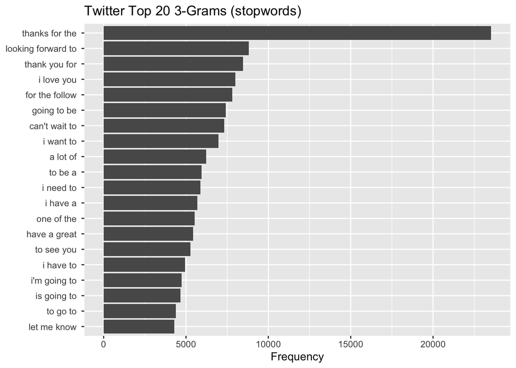

```r
ngrams <- three_gram_df[["ngrams"]]
freq <- three_gram_df[["freq"]]
ggplot(three_gram_df[1:20, ], aes(x = reorder(ngrams, freq), freq)) +
geom_col() + xlab(NULL) + coord_flip() +
labs(title = "Twitter Top 20 3-Grams (stopwords)", x = NULL, y = "Frequency")
```

```r
saveRDS(three_gram_df, "three_gram_df.rds")
```

## 2-gram and 3-gram Exploratory Analysis No Stopwords

After viewing all 1-gram, 2-gram, and 3-gram analysis with stopwords, I thought it would be interesting to view the data with no stopwords. This particular part of the project took a long time as it was reading throughout the text to apply the function I created to read for stopwords. Therefore, I read in the RDS file “Twitter Removal of Stopwords” to save time.

```r
head(readRDS("Twitter Removal of Stopwords"), 20)
```

```
##  [1] "btw thanks rt"
##  [2] "gonna dc anytime soon"
##  [3] "love see"
##  [4] "way"
##  [5] "way long"
##  [6] "meet someone special"
##  [7] "know"
##  [8] "heart beat rapidly smile reason"
##  [9] "decided fun"
## [10] "tired d"
## [11] "played lazer tag & ran lot d"
## [12] "ughh going sleep like 5 minutes"
## [13] "words complete stranger"
## [14] "made birthday even better"
## [15] "first cubs game ever"
## [16] "wrigley field gorgeous"
## [17] "perfect"
## [18] "go cubs go"
## [19] "get another day skool due wonderful snow"
## [20] "wakes"
```

```r
two_gram <- readRDS("2-gram_no_stop.rds")
head(two_gram, 20)
```

```
##              ngrams freq         prop
## 1        right now  3055 0.0014346529
## 2       last night  2136 0.0010030830
## 3  looking forward  1531 0.0007189701
## 4         just got  1301 0.0006109602
## 5        feel like  1262 0.0005926455
## 6       looks like  1158 0.0005438062
## 7          can get  1012 0.0004752434
## 8   happy birthday   942 0.0004423709
## 9         let know   852 0.0004001061
## 10    good morning   813 0.0003817914
## 11       next week   801 0.0003761561
## 12       good luck   759 0.0003564326
## 13     sounds like   751 0.0003526757
## 14     follow back   733 0.0003442228
## 15       make sure   723 0.0003395267
## 16    social media   683 0.0003207424
## 17      first time   655 0.0003075933
## 18        just saw   629 0.0002953835
## 19       look like   611 0.0002869306
## 20       great day   582 0.0002733119
```

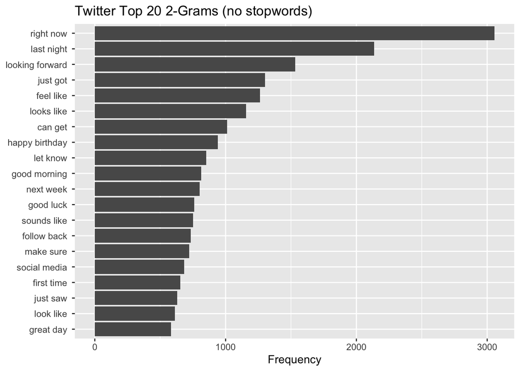

```r
ggplot(two_gram[1:20, ], aes(x = reorder(ngrams, freq), freq)) + geom_col() + xlab(NULL) + coord_flip() +
labs(title = "Twitter Top 20 2-Grams (no stopwords)", x = NULL, y = "Frequency")
```

```r
three_gram <- readRDS("3-gram_no_stop.rds")
head(three_gram, 20)
```

```
##                     ngrams freq         prop
## 1             let us know   413 2.571152e-04
## 2       happy mothers day   287 1.786733e-04
## 3          happy new year   280 1.743154e-04
## 4      happy mother's day   275 1.712026e-04
## 5           cinco de mayo   188 1.170403e-04
## 6  looking forward seeing   160 9.960879e-05
## 7          keep good work   109 6.785849e-05
## 8           just got back   109 6.785849e-05
## 9             come see us   102 6.350060e-05
## 10   please please please   100 6.225549e-05
## 11          just got home    90 5.602994e-05
## 12  good morning everyone    84 5.229461e-05
## 13    thanks following us    83 5.167206e-05
## 14    look forward seeing    80 4.980439e-05
## 15       dreams come true    76 4.731417e-05
## 16     please follow back    75 4.669162e-05
## 17    hope everyone great    74 4.606906e-05
## 18           come join us    71 4.420140e-05
## 19          cant wait see    70 4.357884e-05
## 20         hope great day    69 4.295629e-05
```

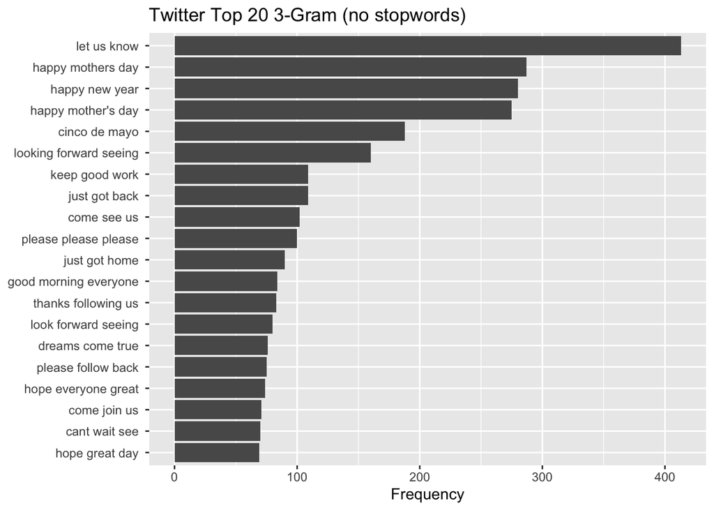

```r
ggplot(three_gram[1:20, ], aes(x = reorder(ngrams, freq), freq)) + geom_col() + xlab(NULL) + coord_flip() + labs(title = "Twitter Top 20 3-Gram (no stopwords)", x = NULL, y = "Frequency")
```

## Distinct Number of Words to cover the Text

```r
#Use the 1-gram
head(one_gram_df, 20)
```

```
##      word frequency
## the   the    929181
## to     to    786567
## i       i    717095
## a       a    608541
## you   you    543257
## and   and    436876
## for   for    384603
## in     in    376652
## of     of    358951
## is     is    357992
## it     it    292620
## my     my    290583
## on     on    276473
## that that    233720
## me     me    201127
## be     be    187131
## at     at    185656
## with with    173172
## your your    170483
## have have    168265
```

```r
one_gram_df[["count"]] <- 1
one_gram_df[["count"]] <- cumsum(one_gram_df[["count"]])
one_gram_df[["coverage"]] <- cumsum(one_gram_df[["frequency"]]) / sum(one_gram_df[["frequency"]]) * 100
one_gram_df_cover <- one_gram_df[one_gram_df[["coverage"]] <= 91,]
head(one_gram_df_cover, 5)
```

```
##     word frequency count  coverage
## the  the    929181     1  3.060054
## to    to    786567     2  5.650439
## i      i    717095     3  8.012034
## a      a    608541     4 10.016130
## you  you    543257     5 11.805228
```

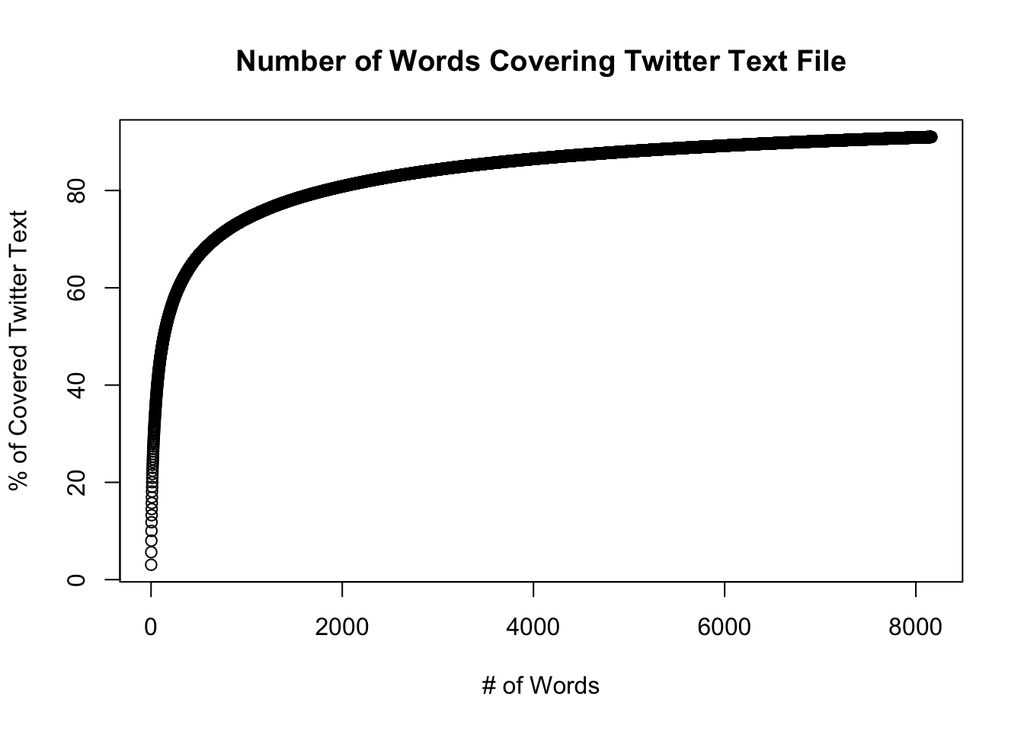

```r
data_points <- rbind(tail(one_gram_df_cover[one_gram_df_cover[["coverage"]] <= 50, ], 1), tail(one_gram_df_cover[one_gram_df_cover[["coverage"]] <= 90, ], 1))
plot(one_gram_df_cover[["coverage"]], main = "Number of Words Covering Twitter Text File", xlab = "# of Words", ylab = "% of Covered Twitter Text")
```

```r
saveRDS(one_gram_df_cover, "one_gram_df_cover.rds")
```

## 1-Gram US News and US Blogs with StopWords Cleaning and Exploratory Analysis

# US News One-Gram

```r
#US News Cleaning Data
#Repeat similar steps as Twitter text data except now for other two texts
us_news <- file("final/en_US/en_US.news.txt", "r")
us_news_lines <- readLines(us_news, skipNul = T)
close(us_news)
lower_us_news <- tolower(us_news_lines)
lower_us_news_updated <- unlist(strsplit(lower_us_news, "[.,:;!?(){}<>]+"))

cleaned_us_news <- lower_us_news_updated %>%
  {gsub("^[^a-z0-9]+|[^a-z0-9]+$", " ", lower_us_news_updated)} %>%
  {gsub("[^a-z0-9]+\\s", " ", lower_us_news_updated)} %>%
  {gsub("\\s[^a-z0-9]+", " ", lower_us_news_updated)} %>%
  {gsub("\\s+", " ", lower_us_news_updated)} %>%
  {str_trim(lower_us_news_updated)}
  head(cleaned_us_news, 20)
```

```
##  [1] "he wasn't home alone"
##  [2] "apparently"
##  [3] "the st"
##  [4] "louis plant had to close"
##  [5] "it would die of old age"
##  [6] "workers had been making cars there since the onset of mass automotive production in the 1920s"
##  [7] "wsu's plans quickly became a hot topic on local online sites"
##  [8] "though most people applauded plans for the new biomedical center"
##  [9] "many deplored the potential loss of the building"
## [10] "the alaimo group of mount holly was up for a contract last fall to evaluate and suggest improvements to trenton water works"
## [11] "but campaign finance records released this week show the two employees donated a total of $4"
## [12] "500 to the political action committee"
## [13] "pac"
## [14] "partners for progress in early june"
## [15] "partners for progress reported it gave more than $10"
## [16] "000 in both direct and in-kind contributions to mayor tony mack in the two weeks leading up to his victory in the mayoral runoff election june 15"
## [17] "and when it's often difficult to predict a law's impact"
## [18] "legislators should think twice before carrying any bill"
## [19] "is it absolutely necessary"
## [20] "is it an issue serious enough to merit their attention"
```

```r
saveRDS(cleaned_us_news, "cleaned_us_news.rds")
#US News 1-Gram
one_gram_us_news <- unlist(strsplit(cleaned_us_news, "\\s+"))
one_gram.frequency_news <- table(one_gram_us_news)
one_gram_df_news <- cbind.data.frame(names(one_gram.frequency_news), as.integer(one_gram.frequency_news))
names(one_gram_df_news) <- c("words", "freq")
row.names(one_gram_df_news) <- one_gram_df_news[,1]
one_gram_df_news <- one_gram_df_news[order(-one_gram_df_news[["freq"]]), ]
head(one_gram_df_news, 20)
```

```
##      words    freq
## the    the 1942453
## to      to  899047
## a        a  882528
## and    and  880450
## of      of  770655
## in      in  670740
## for    for  349506
## that  that  343755
## is      is  282817
## "        "  269099
## on      on  265991
## with  with  253738
## said  said  250358
## was    was  228438
## he      he  221586
## at      at  210619
## it      it  206449
## as      as  185385
## his    his  156985
## be      be  151939
```

```r
one_gram_df_news["i'm", ]
```

```
##     words  freq
## i'm   i'm 12089
```

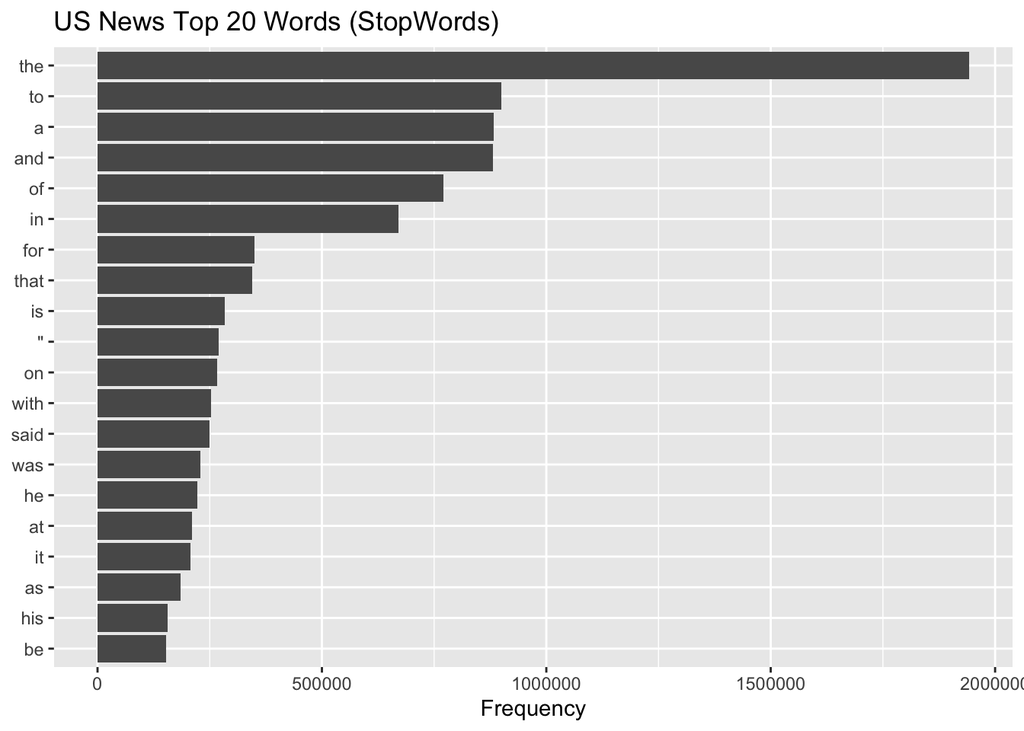

```r
plot_one_gram_df_news <- ggplot(one_gram_df_news[1:20, ], aes(x = reorder(words, freq), freq)) +
geom_col() + xlab(NULL) + coord_flip() +
labs(title = "US News Top 20 Words (StopWords)", x = NULL, y = "Frequency")
plot_one_gram_df_news
```

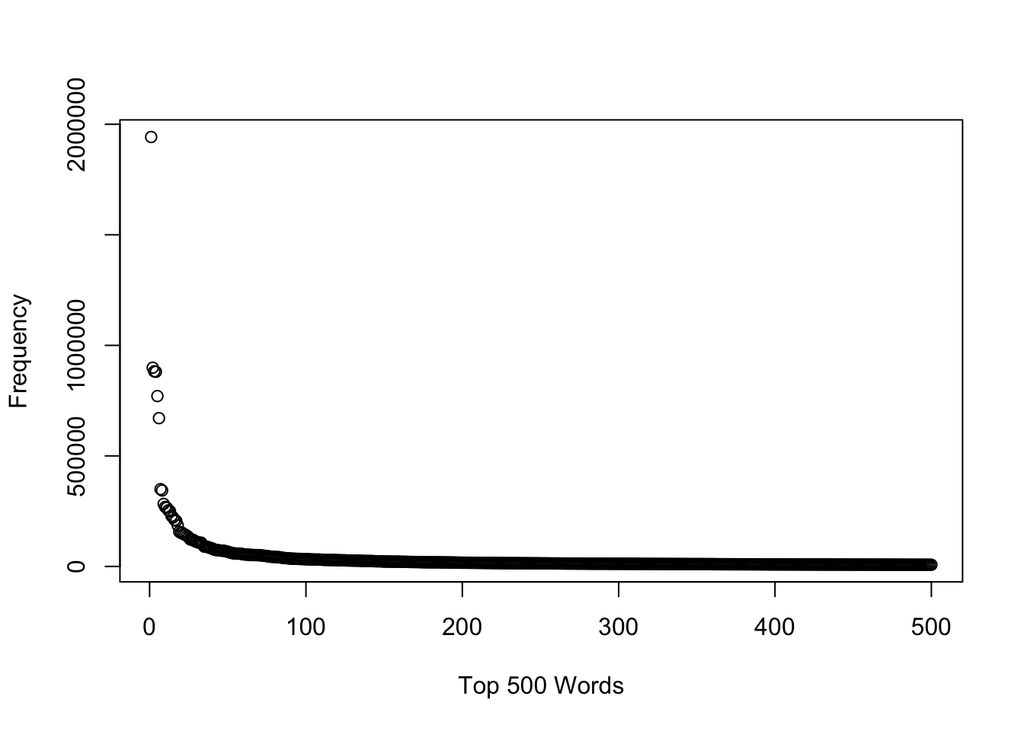

```r
plot(one_gram_df_news[1:500,][["freq"]], xlab = "Top 500 Words", ylab = "Frequency")
```

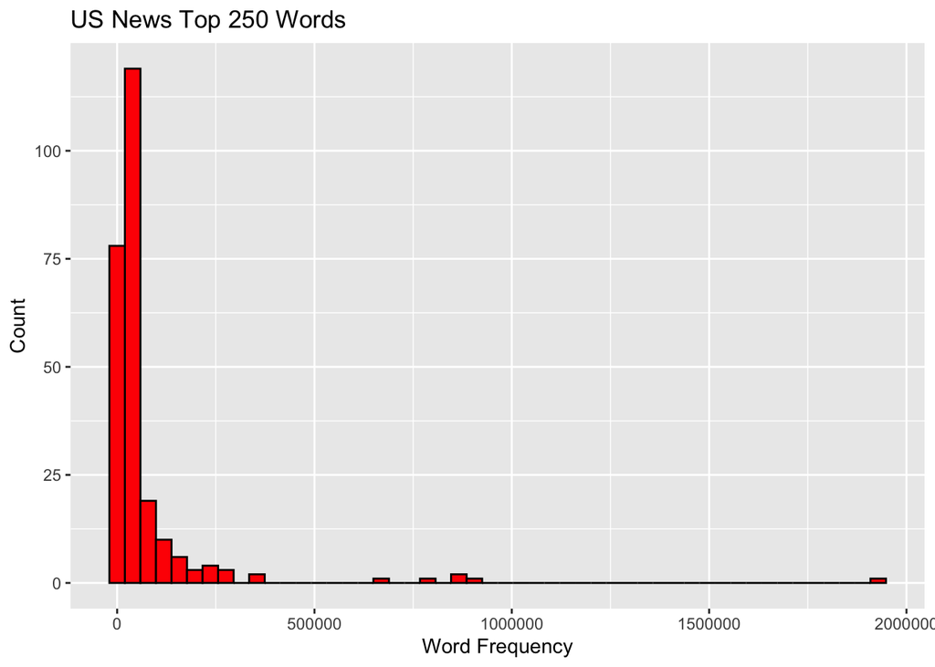

```r
one_gram_histogram_news <- ggplot(one_gram_df_news[1:250, ], aes(x = one_gram_df_news[1:250,][["freq"]])) +
geom_histogram(colour = "black", fill = "red", bins = 50) +
labs(title = "US News Top 250 Words", x = "Word Frequency", y = "Count")
one_gram_histogram_news
```

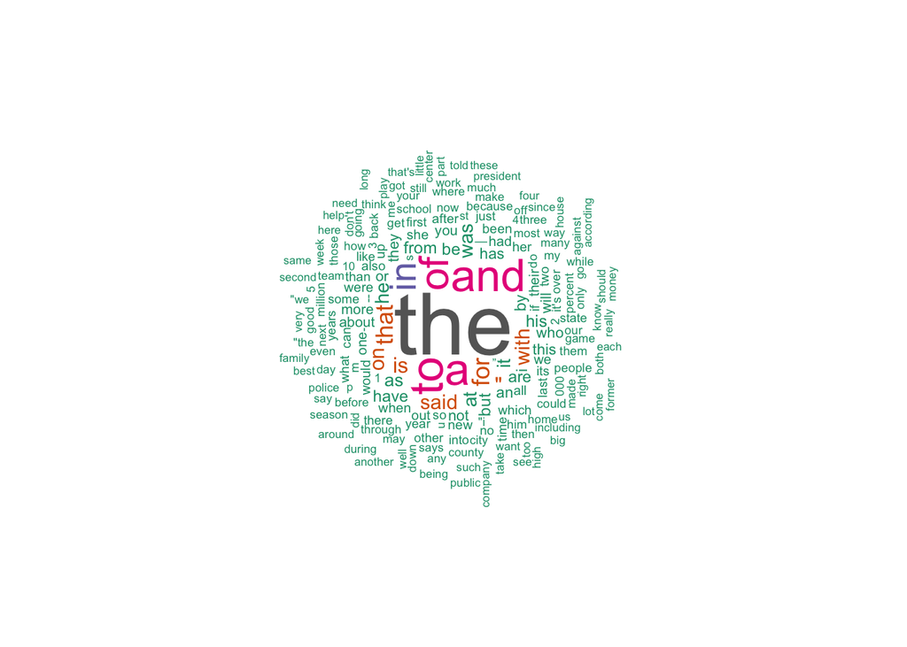

```r
set.seed(1234)
wordcloud(words = one_gram_df_news[["words"]], freq = one_gram_df_news[["freq"]], min.freq = 1, max.words = 200, random.order = F, rot.per = 0.35, colors = brewer.pal(8, "Dark2"))
```

```r
saveRDS(one_gram_df_news, "US_News_One_Gram.rds")
```

# US Blogs One-Gram

```r
#US Blogs Cleaning Data
us_blogs <- file("final/en_US/en_US.blogs.txt", "r")
us_blogs_lines <- readLines(us_blogs, skipNul = T)
close(us_blogs)
lower_us_blogs <- tolower(us_blogs)
lower_us_blogs_updated <- unlist(strsplit(lower_us_news, "[.,:;!?(){}<>]+"))

cleaned_us_blogs <- lower_us_blogs_updated %>%
  {gsub("^[^a-z0-9]+|[^a-z0-9]+$", " ", lower_us_blogs_updated)} %>%
  {gsub("[^a-z0-9]+\\s", " ", lower_us_blogs_updated)} %>%
  {gsub("\\s[^a-z0-9]+", " ", lower_us_blogs_updated)} %>%
  {gsub("\\s+", " ", lower_us_blogs_updated)} %>%
  {str_trim(lower_us_blogs_updated)}
  head(cleaned_us_blogs, 20)
```

[output not shown]

```r
saveRDS(cleaned_us_blogs, "cleaned_us_blogs.rds")
#US Blogs 1-Gram with StopWords
one_gram_us_blogs <- unlist(strsplit(cleaned_us_blogs, "\\s+"))
one_gram.frequency_blogs <- table(one_gram_us_blogs)
one_gram_df_blogs <- cbind.data.frame(names(one_gram.frequency_blogs), as.integer(one_gram.frequency_blogs))
names(one_gram_df_blogs) <- c("wrds", "frq")
row.names(one_gram_df_blogs) <- one_gram_df_blogs[,1]
one_gram_df_blogs <- one_gram_df_blogs[order(-one_gram_df_blogs[["frq"]]), ]
head(one_gram_df_blogs, 20)
```

```
##      wrds     frq
## the   the 1942453
## to     to  899047
## a       a  882528
## and   and  880450
## of     of  770655
## in     in  670740
## for   for  349506
## that that  343755
## is     is  282817
## "       "  269099
## on     on  265991
## with with  253738
## said said  250358
## was   was  228438
## he     he  221586
## at     at  210619
## it     it  206449
## as     as  185385
## his   his  156985
## be     be  151939
```

```r
one_gram_df_blogs["i'm", ]
```

```
##     wrds   frq
## i'm  i'm 12089
```

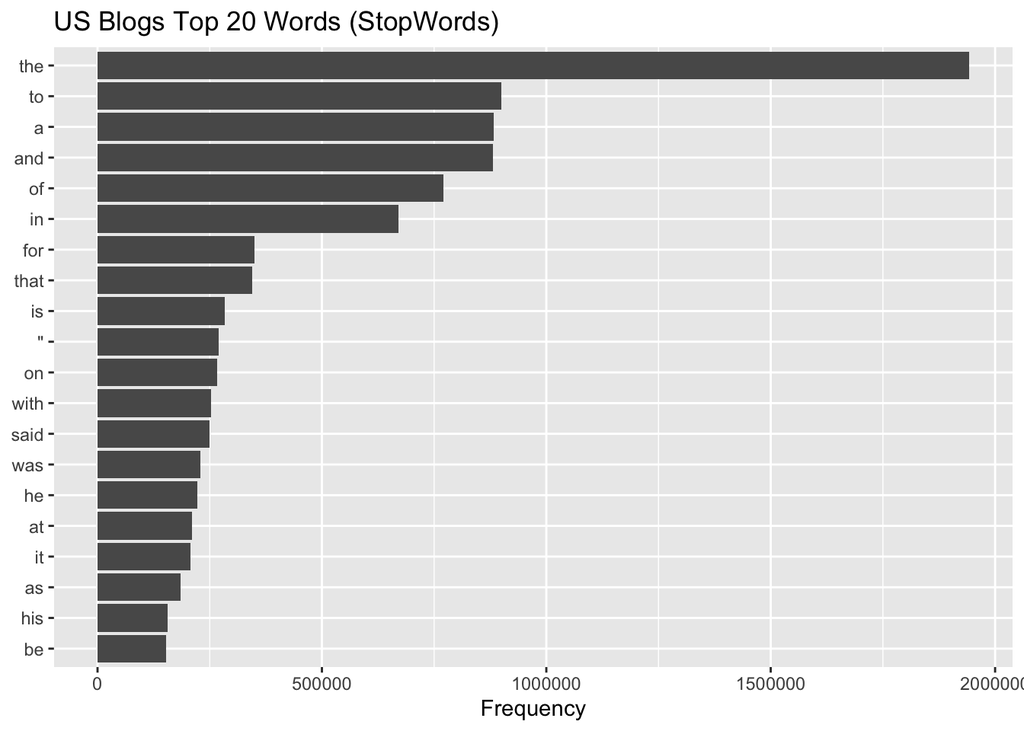

```r
plot_one_gram_df_blogs <- ggplot(one_gram_df_blogs[1:20, ], aes(x = reorder(wrds, frq), frq)) +
geom_col() +
xlab(NULL) +
coord_flip() +
labs(title = "US Blogs Top 20 Words (StopWords)", x = NULL, y = "Frequency")
plot_one_gram_df_blogs
```

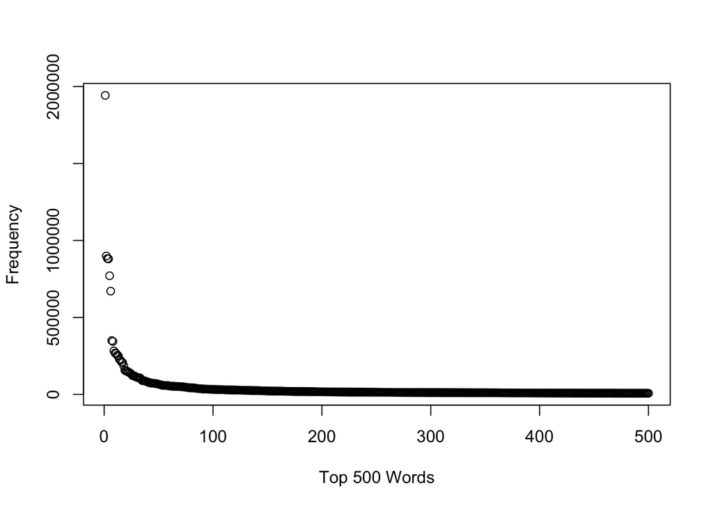

```r
plot(one_gram_df_blogs[1:500,][["frq"]], xlab = "Top 500 Words", ylab = "Frequency")
```

[figure not shown]

```r
one_gram_histogram_blogs <- ggplot(one_gram_df_blogs[1:250, ], aes(x = one_gram_df_blogs[1:250,][["frq"]])) +
geom_histogram(colour = "black", fill = "red", bins = 50) +
labs(title = "US Blogs Top 250 Words", x = "Word Frequency", y = "Count")
one_gram_histogram_news
```

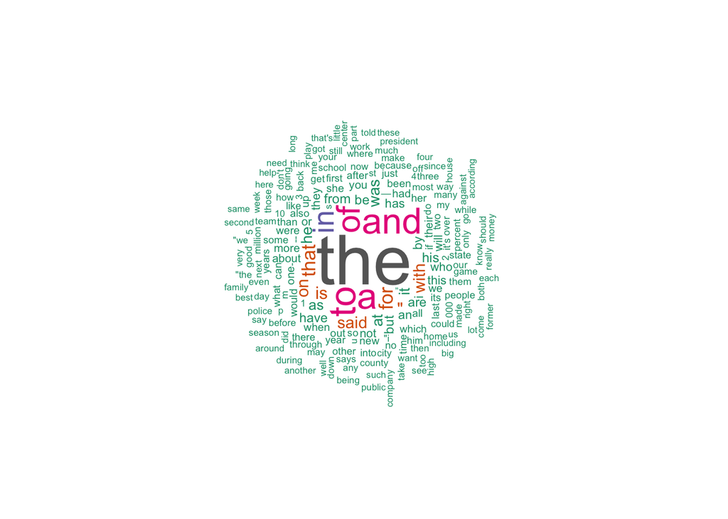

```r
set.seed(1234)
wordcloud(words = one_gram_df_blogs[["wrds"]], freq = one_gram_df_blogs[["frq"]], min.freq = 1, max.words = 200, random.order = F, rot.per = 0.35, colors = brewer.pal(8, "Dark2"))
```

```r
saveRDS(one_gram_df_blogs, "US_Blogs_One_Gram.rds")
```